# COVID-19 Pandemic in the Taiwan

K.N.Sathsara - AS2021402

2024-07-29

## **Introduction about Taiwan**

> Taiwan, officially known as the Republic of China (ROC), is an island nation in East Asia with a vibrant economy and rich cultural heritage. Located off the southeastern coast of China, Taiwan boasts a diverse landscape, from bustling cities like Taipei to lush, mountainous regions. Its history is marked by indigenous cultures, colonial influences, and significant political changes, particularly after 1949 when the ROC government retreated to Taiwan following the Chinese Civil War. Despite its complex international status and limited diplomatic recognition, Taiwan functions as a sovereign state with its own government, military, and democratic political system. Known globally for its advanced technology sector, especially in semiconductor production, Taiwan also maintains a high standard of living and a progressive society, leading in various social issues such as LGBTQ+ rights. The island’s unique blend of traditional Chinese, Japanese, and indigenous cultures is reflected in its festivals, cuisine, and arts, making Taiwan a dynamic and influential player on the world stage.

##### **Capital City**

- Taipei City (GMT +8)

##### **Currency**

- New Taiwan dollar

##### **Population**

- 23.57 million (2020)

##### **Dialing Code**

- +886

##### **President**

- Lai Ching Te

##### **Religions** (2020 estimate)

- Buddhism 35.1%
- Taosim 33.0%
- No religion 18.7%
- Christianity 3.9%

##### **Neighboring Countries**

- China
- Japan
- Philippines

## **COVID-19 Pandemic in Taiwan**

> The COVID-19 pandemic in Taiwan was a part of the worldwide pandemic of coronavirus disease 2019 (COVID-19) caused by severe acute respiratory syndrome coronavirus 2 (SARS-CoV-2).

> The virus was confirmed to have spread to Taiwan on 21 January 2020, with the first case being a 50-year-old woman who had been teaching in Wuhan, China.[6] The Taiwanese government integrated data from the national health care system, immigration, and customs authorities to aid in the identification and response to the virus.

> Starting 19 March 2020, foreign nationals were barred from entering Taiwan with some exceptions such as those carrying out the remainder of business contracts and those holding valid Alien Resident Certificates, diplomatic credentials, or other official documentation and special permits. Restrictions have since been relaxed for foreign university students and those seeking medical treatment in Taiwan, subject to prior government approval.All who are admitted into the country must complete a fourteen-day quarantine upon arrival, except for business travelers from countries determined to be at low or moderate risk, who are subject to five- or seven-day quarantines and must submit to a COVID-19 test.

## **Exploratory Data Analysis**

### **Structure of Data**

##### Daily summary of the Coronavirus (COVID-19) cases by state/province.

#### **Format**

A data frame with following variables.

**date :** Date in YYYY-MM-DD format.

**province :** Name of province/state, for countries where data is provided split across multiple provinces/states.

**country :** Name of country/region.

**lat :** Latitude of center of geographic region, defined as either country or, if available, province.

**long :** Longitude of center of geographic region, defined as either country or, if available, province.

**type :** An indicator for the type of cases (confirmed, death, recovered).

**cases :** Number of cases on given date.

**uid :** Country code

**iso2 :** Officially assigned country code identifiers with two-letter

**iso3 :** Officially assigned country code identifiers with three-letter

**code3 :** UN country code

**combined_key :** Country and province (if applicable)

**population :** Country or province population

**continent_name :** Continent name

**continent_code :** Continent code

##### **Details :**

The dataset contains the daily summary of Coronavirus cases (confirmed, death, and recovered), by state/province.

### **Summary about the Filtered Taiwan Corona Dataset**

```
##       date              province           country               lat
##  Min.   :2020-01-22   Length:3429        Length:3429        Min.   :23.7
##  1st Qu.:2020-11-02   Class :character   Class :character   1st Qu.:23.7
##  Median :2021-08-15   Mode  :character   Mode  :character   Median :23.7
##  Mean   :2021-08-15                                         Mean   :23.7
##  3rd Qu.:2022-05-28                                         3rd Qu.:23.7
##  Max.   :2023-03-09                                         Max.   :23.7
##       long         type               cases             uid
##  Min.   :121   Length:3429        Min.   :  -266   Min.   :158
##  1st Qu.:121   Class :character   1st Qu.:     0   1st Qu.:158
##  Median :121   Mode  :character   Median :     0   Median :158
##  Mean   :121                      Mean   :  2917   Mean   :158
##  3rd Qu.:121                      3rd Qu.:    17   3rd Qu.:158
##  Max.   :121                      Max.   :128954   Max.   :158
##      iso2               iso3               code3     combined_key
##  Length:3429        Length:3429        Min.   :158   Length:3429
##  Class :character   Class :character   1st Qu.:158   Class :character
##  Mode  :character   Mode  :character   Median :158   Mode  :character
##                                        Mean   :158
##                                        3rd Qu.:158
##                                        Max.   :158
##    population       continent_name     continent_code
##  Min.   :23816775   Length:3429        Length:3429
##  1st Qu.:23816775   Class :character   Class :character
##  Median :23816775   Mode  :character   Mode  :character
##  Mean   :23816775
##  3rd Qu.:23816775
##  Max.   :23816775
```

> This is the summary about filtered data set Taiwan from the coronavirus data set. So can see in “cases” column there are some minus values here.Cases cannot be minus. That is error. So, we do some statistical things to avoid this error. The data set has data from 2020-01-22 to 2023-03-09. According to the above summary we can see the mean number of cases are 2917. The maximum number of cases are 128954.

### **Confirmed Corona Cases in Taiwan**

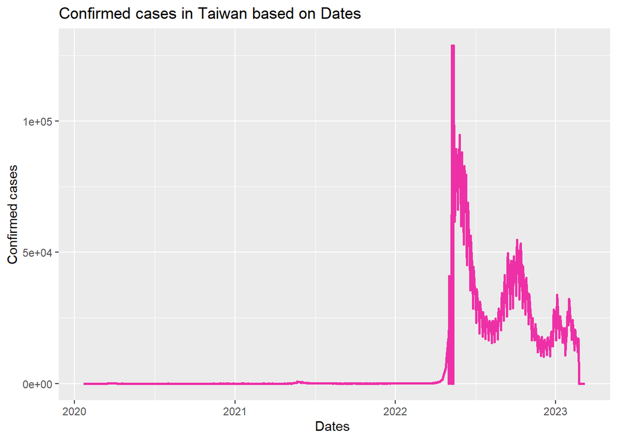

> In Confirmed cases there had two minus values.So I did some statistical operations and correct them.

> According to the above plot,In Initial period(2020-early 2021) we can see that there is a very low number of cases indicating that Taiwan had very few cases during that period.In the period of mid 2021 to early 2022 there is noticeable increase in cases,although still relatively low compared to the later period. In mid 2022 a significant spike in the number of confirmed cases is observed,reaching the peak around mid 2022. After that peak period there is a sharp decline in the number of cases confirmed.

### **Death Corona Cases in Taiwan**

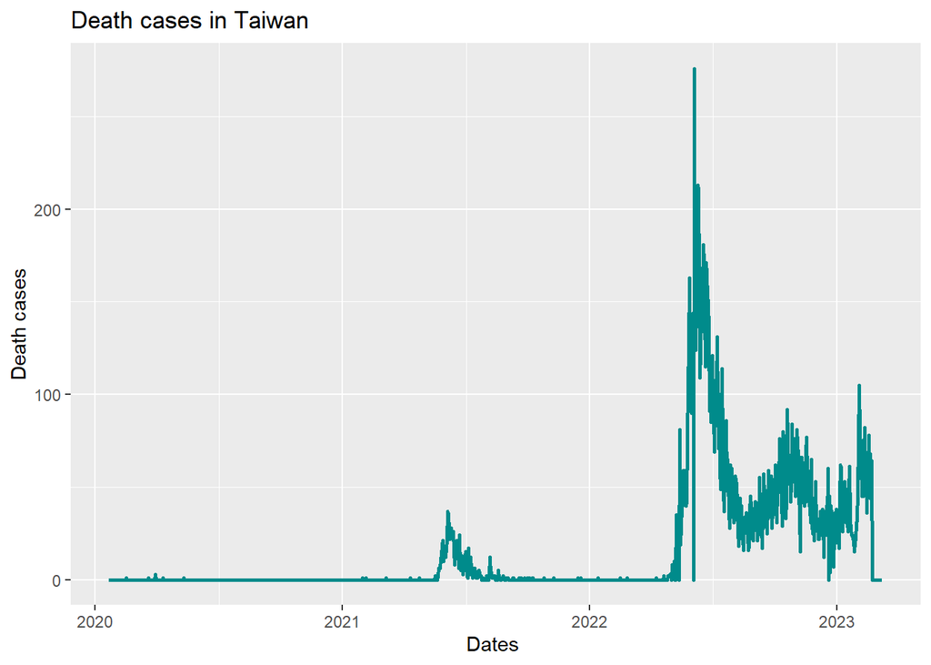

> According to the above graph, In initial period (2020 to early 2021) the graph shows a very low number of death cases in the initial period of the pandemic. In mid 2021 to early 2022 there is a noticeable increase in the number of death cases starting from mid 2021. After that there is a significant spike in the number of death cases is observed around mid 2022. After that peak period there is a sharp decline in the number of death cases.

### **Recovery Corona Cases in Taiwan**

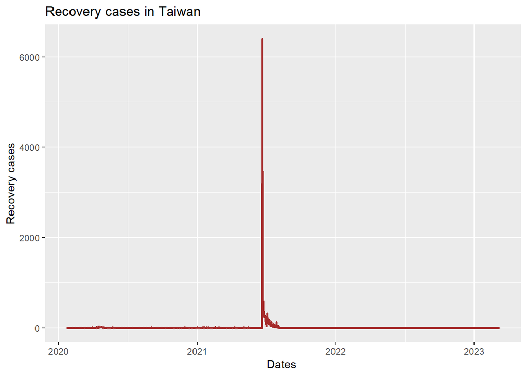

> In Recovery cases there had a one minus values.So I did some statistical operations and correct them.

### **Active Cases In Taiwan**

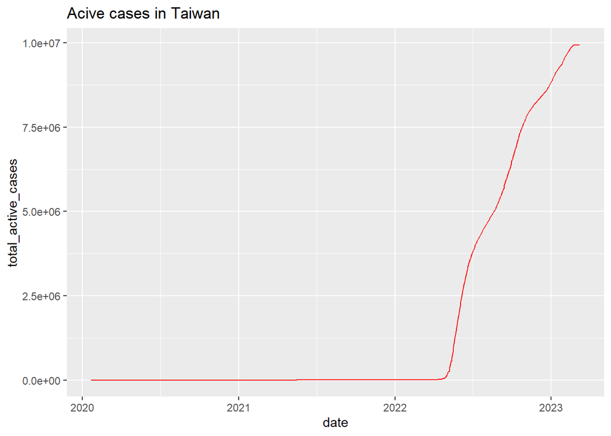

> According to the graph we can conclude that most of active cases had between mid 2022 to early 2023.

### **Compare Confirmed Cases with China,Japan and Philippines**

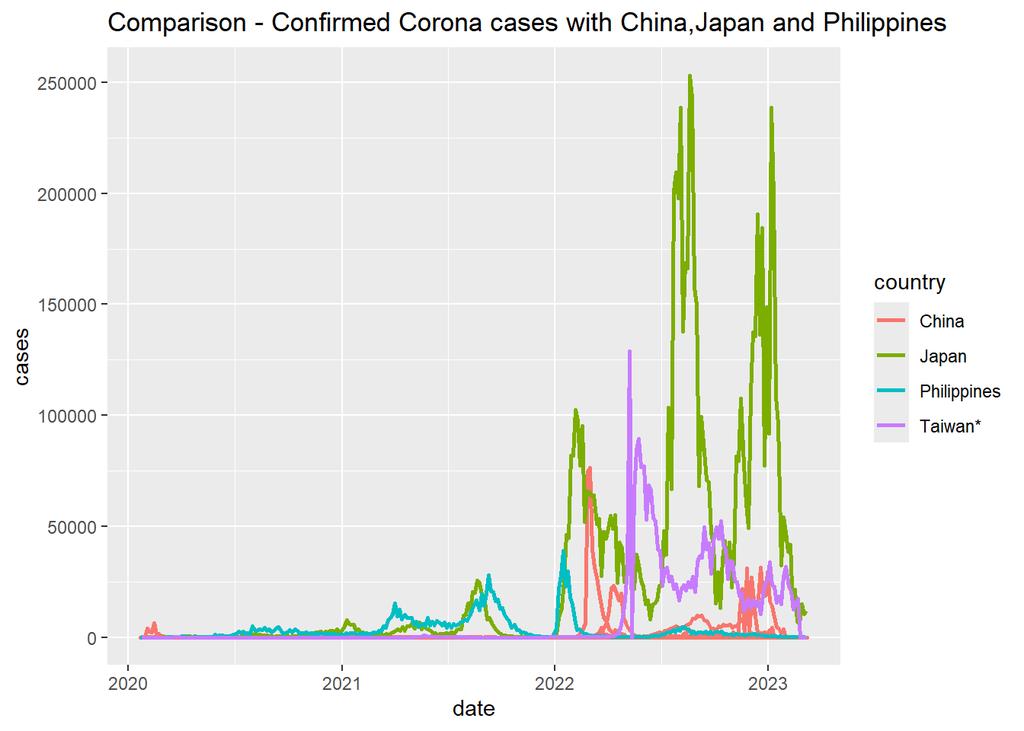

> According to the Figure, we can say that Japan has the highest confirmed corona cases. As well as Philippines has the lowest confirmed corona cases.

### **Compare Death Cases with China,Japan and Philippines**

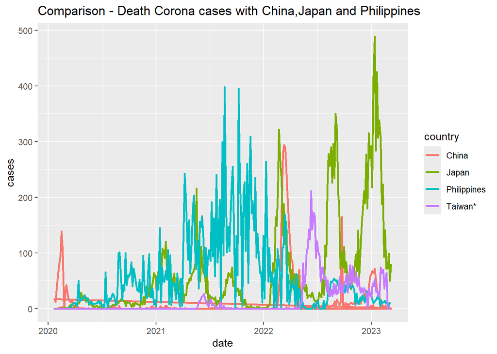

> According to the Figure, we can say that Japan has the highest daily death corona cases. As well as Taiwan has the lowest daily death corona cases.

### **Compare Recovery Cases with China,Japan and Philippines**

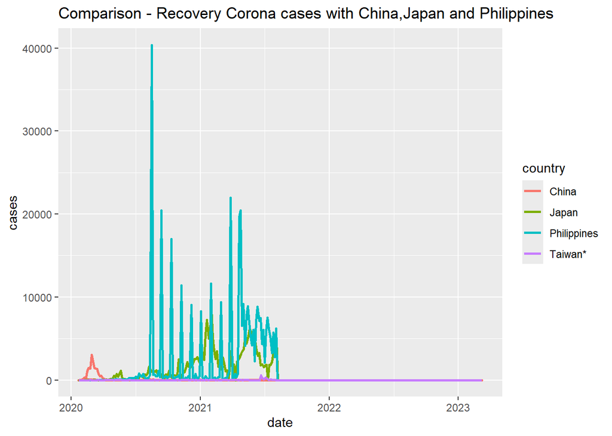

> According to the Figure, we can say that Philippines has the highest recovery corona cases. As well as Taiwan has the lowest recovery corona cases.

### **References**

- [Introduction about Taiwan](https://en.wikipedia.org/wiki/Taiwan#:~:text=Taiwan%2C%20officially%20the%20Republic%20of,the%20Philippines%20to%20the%20south.)
- [COVID-19 pandemic in Taiwan](https://en.wikipedia.org/wiki/COVID-19_pandemic_in_Taiwan)